# Data 624 - Assignment 9

John Kellogg

5/1/2021

# Assignment

Do problems 8.1, 8.2, 8.3, and 8.7 in Kuhn and Johnson. Please submit the Rpubs link along with the .rmd file.

## 8.1. Recreate the simulated data from Exercise 7.2:

```r
library(mlbench)
set.seed(200)
simulated <- mlbench.friedman1(200, sd = 1)
simulated <- cbind(simulated$x, simulated$y)
simulated <- as.data.frame(simulated)
colnames(simulated)[ncol(simulated)] <- "y"
```

### (a)

Fit a random forest model to all of the predictors, then estimate the variable importance scores:

```r
library(randomForest)
library(caret)
model1 <- randomForest(y ~ ., data = simulated,
  importance = TRUE,
  ntree = 1000)

(rfImp1 <- varImp(model1, scale = FALSE))
```

```
##          Overall
## V1   8.732235404
## V2   6.415369387
## V3   0.763591825
## V4   7.615118809
## V5   2.023524577
## V6   0.165111172
## V7  -0.005961659
## V8  -0.166362581
## V9  -0.095292651
## V10 -0.074944788
```

Did the random forest model significantly use the uninformative predictors (V6 – V10)?

- We can see the model prefered using V1, V2, V4, & V5
- The numbers significantly dropoff at v6

### (b)

Now add an additional predictor that is highly correlated with one of the informative predictors. For example:

```r
set.seed(42)
simulated$duplicate1 <- simulated$V1 + rnorm(200) * .1
cor(simulated$duplicate1, simulated$V1)
```

```
## [1] 0.9474738
```

```r
model2 <- randomForest(y ~.,data = simulated, importance = TRUE, ntree = 1000)
(rfImp2 <- varImp(model2, scale = FALSE))
```

```
##                 Overall
## V1          5.728986628
## V2          6.412446011
## V3          0.575827693
## V4          6.869034596
## V5          1.854388474
## V6          0.119361481
## V7          0.068594729
## V8         -0.101954255
## V9         -0.045573011
## V10        -0.004545964
## duplicate1  4.065846686
```

Fit another random forest model to these data. Did the importance score for V1 change? What happens when you add another predictor that is also highly correlated with V1?

### (c)

Use the cforest function in the party package to fit a random forest model using conditional inference trees. The party package function varimp can calculate predictor importance. The conditional argument of that function toggles between the traditional importance measure and the modified version described in Strobl et al. (2007). Do these importances show the same pattern as the traditional random forest model?

#### Unconditional Model

```r
library(party)
set.seed(42)
model3 <- cforest(y ~ ., data=simulated)

(rfImp3.1 <-varimp(model3))
```

```
##           V1           V2           V3           V4           V5
##  5.328641116  6.214681004  0.035890572  7.493812388  1.726478786
##           V6           V7           V8           V9          V10
##  0.007643556  0.023774531  0.001531523 -0.041759658 -0.044348765
##   duplicate1
##  4.023060689
```

#### Conditional Model

```r
(rfImp3.2 <-varimp(model3, conditional = TRUE))
```

```
##           V1           V2           V3           V4           V5
##  2.271913677  4.884311743  0.035971152  5.732232418  1.137963934
##           V6           V7           V8           V9          V10
##  0.009634587  0.004156491 -0.009771291  0.001793470 -0.041067113
##   duplicate1
##  1.573509257
```

- V1 dropped between the Unconditional vs Conditional model
- Neither model improved or made significant V6-V10
- The Duplicate value also dropped due to being tied to V1.

### (d)

Repeat this process with different tree models, such as boosted trees and Cubist. Does the same pattern occur?

```r
library(Cubist)
model4 <- cubist(x=simulated[,-(ncol(simulated)-1)], y=simulated$y, committees=100)
as.data.frame(as.matrix(varImp(model4)))
```

```
##            Overall
## V3            50.0
## V1            63.0
## V2            59.5
## duplicate1    19.0
## V4            47.0
## V5            27.5
## V6             6.0
## V8             3.0
## V7             0.0
## V9             0.0
## V10            0.0
```

- The general pattern holds with the cubist model; V1-V5 are the significant
  - V3 and V1 seem to have flipped

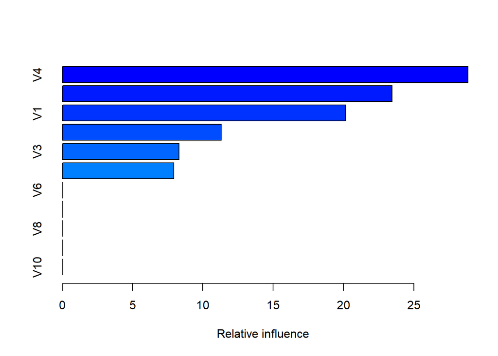

```
##                   var   rel.inf
## V4                 V4 28.848679
## V2                 V2 23.449429
## V1                 V1 20.149563
## V5                 V5 11.314774
## V3                 V3  8.314535
## duplicate1 duplicate1  7.923020
## V6                 V6  0.000000
## V7                 V7  0.000000
## V8                 V8  0.000000
## V9                 V9  0.000000
## V10               V10  0.000000
```

```r
library(gbm)
model5 <- gbm(y ~ ., data = simulated, distribution='gaussian')
summary(model5)
```

- No real change in the pattern of V1-V5 being top significance.
- V7-V10 are now 0 value

```r
library(ipred)
model6 <- bagging(y ~ ., data=simulated, nbagg = 50)
varImp(model6)
```

```
##              Overall
## duplicate1 1.4310911
## V1         1.7815560
## V10        0.6879357
## V2         2.1455855
## V3         1.1327432
## V4         2.6994292
## V5         2.3372899
## V6         0.8837772
## V7         0.9605533
## V8         0.5666207
## V9         0.5641154
```

## 8.2.

Use a simulation to show tree bias with different granularities.

```r
library(rpart)

set.seed(42)
X1 <- rep(1:2, each=100)
X2 <- rnorm(200, mean = 0, sd = 2)
Y <- X1 + rnorm(200, mean = 0, sd = 4)
sim <- data.frame(Y = Y, X1 = X1, X2 = X2)

model7 <- rpart(Y~., data = sim)

as.data.frame(as.matrix(varImp(model6)))
```

[output not shown]

## 8.3.

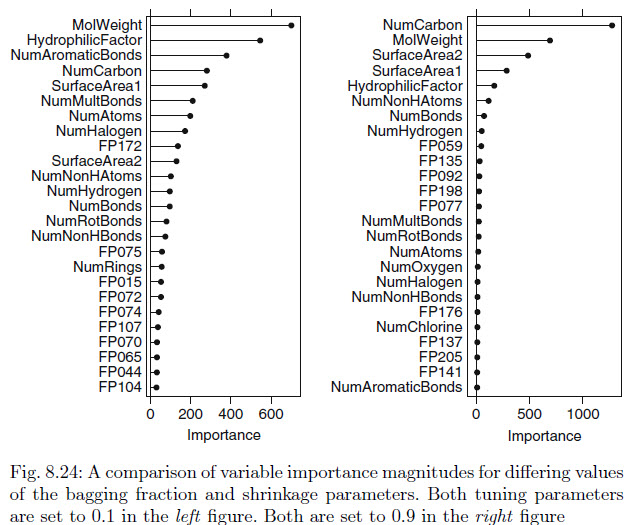

Figure 8.24

In stochastic gradient boosting the bagging fraction and learning rate will govern the construction of the trees as they are guided by the gradient. Although the optimal values of these parameters should be obtained through the tuning process, it is helpful to understand how the magnitudes of these parameters affect magnitudes of variable importance. Figure 8.24 provides the variable importance plots for boosting using two extreme values for the bagging fraction (0.1 and 0.9) and the learning rate (0.1 and 0.9) for the solubility data. The left-hand plot has both parameters set to 0.1, and the right-hand plot has both set to 0.9:

### (a)

Why does the model on the right focus its importance on just the first few of predictors, whereas the model on the left spreads importance across more predictors?

### (b)

Which model do you think would be more predictive of other samples?

- Left due to the smaller learning rate and bagging fraction being more robust.

### (c)

How would increasing interaction depth affect the slope of predictor importance for either model in Fig. 8.24?

## 8.7

Refer to Exercises 6.3 and 7.5 which describe a chemical manufacturing process. Use the same data imputation, data splitting, and pre-processing steps as before and train several tree-based models:

### (a)

Which tree-based regression model gives the optimal resampling and test set performance?

```r
library(AppliedPredictiveModeling)
data("ChemicalManufacturingProcess")
set.seed(42)

predictors <- subset(ChemicalManufacturingProcess, select=-Yield)
yield <- subset(ChemicalManufacturingProcess, select="Yield")

traindata <- createDataPartition(yield$Yield, p = .80, list = FALSE)

x_train <- predictors[traindata,]
y_train <- yield[traindata,]

x_test <- predictors[-traindata,]
y_test <- yield[-traindata,]

nearzero_pred <- nearZeroVar(x_train)
train_predictors <- x_train[-nearzero_pred]
test_predictors <- x_test[-nearzero_pred]

#pp <- preProcess(trans_x_train, method = c("BoxCox","center","scale","knnImpute"))
#trans_x_train <- predict(pp, trans_x_train)
#trans_x_test <- predict(pp, trans_x_test)


train_yield <- yield[traindata,]
test_yield <- yield[-traindata,]

tune_param <- trainControl(method = "boot", number = 25)
```

#### Regression Tree with classification

```r
rtgrid <- expand.grid(maxdepth=seq(1,10,by=1))
rtmodel <- train(x=train_predictors, y = train_yield, method = "rpart2",
                   metric = "Rsquared", tuneGrid = rtgrid, trControl = tune_param)

rtpred <- predict(rtmodel, test_predictors)
postResample(pred = rtpred, obs = test_yield)
```

```
##      RMSE  Rsquared       MAE
## 1.4975688 0.4505364 1.1151924
```

#### Cubist

```r
cubegrid <- expand.grid(committees = c(1,5,10,20,50,100),neighbors = c(0,1,3,5,7))

cubemodel <- train(x=train_predictors, y = train_yield, method = "cubist",
                   metric = "Rsquared", tuneGrid = cubegrid, trControl = tune_param)

cubepred <- predict(cubemodel, test_predictors)
postResample(pred = cubepred, obs = test_yield)
```

```
##      RMSE  Rsquared       MAE
## 0.9874126 0.7781003 0.7292328
```

#### GBM

```r
gbmgrid <- expand.grid(interaction.depth=seq(1,6,by=1),n.trees=c(25,50,100,200),shrinkage=c(0.01,0.05,0.1,0.2),n.minobsinnode=c(5, 10, 15))

gbmmodel <- train(x=train_predictors, y = train_yield, method = "gbm",
                   metric = "Rsquared", tuneGrid = gbmgrid, trControl = tune_param, verbose = FALSE)

gbmpred <- predict(gbmmodel, test_predictors)
postResample(pred = gbmpred, obs = test_yield)
```

```
##      RMSE  Rsquared       MAE
## 1.2086588 0.6606338 0.8786583
```

### (b)

Which predictors are most important in the optimal tree-based regression model? Do either the biological or process variables dominate the list? How do the top 10 important predictors compare to the top 10 predictors from the optimal linear and nonlinear models?

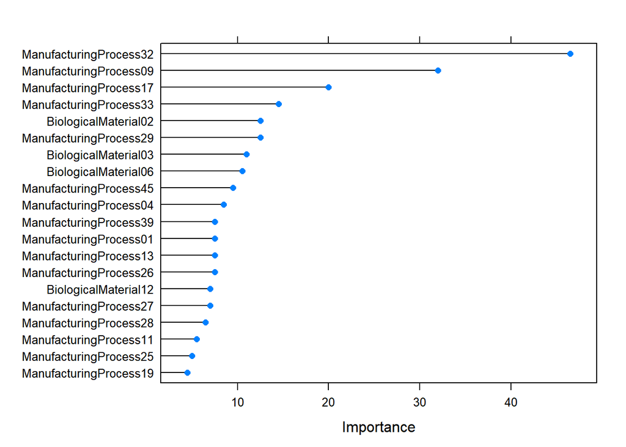

```r
cubist_imp <- varImp(cubemodel, scale = FALSE)
plot(cubist_imp, top=20, scales = list(y=list(cex=0.8)))
```

Manufacturing Processes dominate the top predictors, again * MP32 is the top predictor in botrh model styles * MP9 and 17 are also in the top 5 of both styles

### (c)

Plot the optimal single tree with the distribution of yield in the terminal nodes. Does this view of the data provide additional knowledge about the biological or process predictors and their relationship with yield?

```r
library(partykit)
```

[figure not shown]

```r
plot(as.party(rtmodel$finalModel))
```

- It doesn’t help me at this time, I’m sure it will in the future.